# HiCaptuRe Functions

Laureano Tomás-Daza

2023-12-11

In this vignette we will show you the main functions of HiCapture and how they work. To start playing with the function first we need some example data provided in the package. Let’s save them in variables:

```r
ibed1 <- system.file("extdata", "ibed1_example.ibed", package="HiCaptuRe")
ibed2 <- system.file("extdata", "ibed2_example.ibed", package="HiCaptuRe")
annotation <- system.file("extdata", "annotation_example.txt", package="HiCaptuRe")
regions <- system.file("extdata", "regions_example.bed", package="HiCaptuRe")
```

```r
library(HiCaptuRe)
```

# Importing interaction data: `load_interactions`

The first step is loading the interaction file into R, to do so we use the function `load_interactions`.

This function reads the file and removes some “technical artefacts” of Chicago, like duplicated interactions. And it gives us the interactions in an easy readable format, a `HiCaptuRe` object, which contains a `GenomicInteractions` object.

We can load different types of interaction files: ibed, seqmonk, washU (and it old format), bedpe and peakmatrix. The function detect automatically which is the format of our file.

```r
ibed1 <- load_interactions(file = ibed1)
```

```
## ibed1_example.ibed is in ibed format
```

```
##
## 547 interactions removed
##  - 0 interactions were real duplicates
##  - 547 interactions duplicated with different Chicago Score
```

We can see that it detects that the file is in ibed format. And the function removes several interactions duplicated.

```r
ibed1
```

```
## HiCaptuRe object with 12314 interactions and 9 metadata columns:
##           seqnames1             ranges1     seqnames2             ranges2 |
##               <Rle>           <IRanges>         <Rle>           <IRanges> |
##       [1]         1       896515-912788 ---         1       915239-938701 |
##       [2]         1       896515-912788 ---         1       954044-968260 |
##       [3]         1       896515-912788 ---         1       968261-992014 |
##       [4]         1       896515-912788 ---         1     1271494-1277058 |
##       [5]         1       912789-915238 ---         1       954044-968260 |
##       ...       ...                 ... ...       ...                 ... .
##   [12310]         1 248848416-248864101 ---         1 248867497-248877355 |
##   [12311]         1 248904200-248908640 ---         1 248909696-248918036 |
##   [12312]         1 248909696-248918036 ---         1 248619193-248621583 |
##   [12313]         1 248909696-248918036 ---         1 248701066-248710695 |
##   [12314]         3   25173169-25175068 ---         1 218700013-218710623 |
##                           bait_1      ID_1                 bait_2      ID_2
##                      <character> <integer>            <character> <integer>
##       [1] ENST00000448179,ENST..       237 ENST00000616016,ENST..       239
##       [2] ENST00000448179,ENST..       237 ENST00000379410,ENST..       242
##       [3] ENST00000448179,ENST..       237 ENST00000480267,ENST..       243
##       [4] ENST00000448179,ENST..       237 ENST00000450390,ENST..       273
##       [5]        ENST00000398216       238 ENST00000379410,ENST..       242
##       ...                    ...       ...                    ...       ...
##   [12310] ENST00000463519,ENST..     65273                      .     65276
##   [12311] ENST00000355360,ENST..     65289        ENST00000363625     65291
##   [12312]        ENST00000363625     65291                      .     65213
##   [12313]        ENST00000363625     65291                      .     65243
##   [12314]        ENST00000383772    149736                      .     56584
##               reads        CS    counts         int  distance
##           <integer> <numeric> <integer> <character> <numeric>
##       [1]        51     27.54         1         B_B     22318
##       [2]        10      6.39         1         B_B     56500
##       [3]        10      7.00         1         B_B     75486
##       [4]         5      6.84         1         B_B    369624
##       [5]        23      8.15         1         B_B     47138
##       ...       ...       ...       ...         ...       ...
##   [12310]        96     10.09         1        B_OE     16167
##   [12311]       156      5.42         1         B_B      7446
##   [12312]        10      5.20         1        B_OE    293478
##   [12313]        13      5.72         1        B_OE    207985
##   [12314]         3      5.86         1        B_OE        NA
##   -------
##   regions: 7469 ranges and 4 metadata columns
##   seqinfo: 24 sequences from GRCh38 genome
```

The resulting `HiCaptuRe` object looks like a `GenomicInteractions` object but with some extra slots. This object contains the coordinates of both anchors of the interaction and metadata:

- `bait_1` and `bait_2` : annotation of each restriction fragment, in case one of them does not have annotation it shows a dot (“.”)

- `ID_1` and `ID_2` : the ID of the restriction fragment when digesting the genome with an specific restriction enzyme. This ID comes from the function `digest_genome` .

- `reads` : The number of reads detected in each interaction.

- `CS` : The Chicago Score of each interaction.

- `counts` : It’s a column added when creating a `GenomicInteractions` object, that tells the number of times that each interaction appears, in this case it will always be 1.

- `int` : The type of interaction. It could be B_B or B_OE, meaning interaction between 2 baits (B_B) or between a bait and an other-end (B_OE).

- `distance` : The distance between the midpoint of the anchors of the interactions.

**NOTE**: When loading certain type of files, such as WashU format or bedpe, they lack of some information such as the number of reads or the annotation. In these cases the function assigns a value to these columns. In the annotation it adds “non-annotated” to all fragments and in the reads columns it adds a zero to all of them.

Now, let’s have a look at the new extra slots of the `HiCaptuRe` object.

```r
slotNames(ibed1)
```

```
## [1] "parameters"      "ByBaits"         "ByRegions"       "anchor1"
## [5] "anchor2"         "regions"         "NAMES"           "elementMetadata"
## [9] "metadata"
```

There are several slots that belong to the `GenomicInteractions` object, the new ones are: **parameters**, **ByBaits** and **ByRegions**.

These slots are filled while running certain functions, with this function we have only initialize the slot parameters, so let’s have a look at it:

```r
ibed1@parameters
```

```
## $digest
##                                                                      Genome
##                                                                    "GRCh38"
##                                                              Genome_Package
##                                             "BSgenome.Hsapiens.NCBI.GRCh38"
##                                                          Restriction_Enzyme
##                                                                   "hindIII"
##                                                                       Motif
##                                                                    "AAGCTT"
##                                                                Cut_Position
##                                                                         "1"
##                                                        Selected_Chromosomes
##              "1,2,3,4,5,6,7,8,9,10,11,12,13,14,15,16,17,18,19,20,21,22,X,Y"
##                                                                    PAR_mask
##                                                                      "TRUE"
##                                                                    PAR_file
## "/home/ltomas/MEGA/HiCaptuRe/inst/extdata/PAR_Homo_sapiens_coordinates.txt"
##
## $load
##                                                          file
## "/home/ltomas/MEGA/HiCaptuRe/inst/extdata/ibed1_example.ibed"
##                                                          type
##                                                        "ibed"
```

This slot contains a list with the parameters used to run each function.

So we can see that the last step that we run was “load” and the 2 arguments used in this function. But we can see that there is another step before called “digest”. This step refers to the function `digest_genome`.

## Digesting the Genome: `digest_genome`

This function generates the restriction fragments resulting from the virtual digestion of a given genome. The default arguments are for the restriction enzyme HindIII in the genome version GRCh38.

There are some interesting arguments:

- `RE_name`, `motif` and `cut_position`. These arguments refer to the restriction enzyme used to digest the genome. We have to indicate the recognition motif of the enzyme and the cut position of the enzyme inside that motif.
- `select_chr`. In most genome there are more chromosomes than the commonly known (1:22, X, Y), so here we can specify which chromosomes we want to digest
- `PAR_mask` and `PAR_file`. Pseudoautosomical Regions (PAR) are regions of the sexual chromosomes that are equal between X and Y, and in certain genomes might be masked. For example in Ensembl human genome the PAR region of chromosome Y is mask, while in UCSC version is not. This fact affects the digestion of the genome, only in chromosome Y, generating different restriction fragments depending on the version. With these 2 arguments we can specify if we want to mask those regions and provide a file with the coordinates of such regions. The package already contains the PAR coordinates for the GRCh38 genome.

**NOTE**: This function is internally called each time we run `load_interactions` to provide the ID of the restriction fragment so each file that we load have the same IDs. The first time that `digest_genome` is called takes a while to digest a certain genome, but the next times is much faster since the digested genome is saved on cache.

# Annotating interaction object: `annotate_interactions`

This function allows us to annotate the baits of the interactions, particularly useful when loading files without annotation such as WashU format or bedpe files.

When performing a C-HiC experiment we need a capture library, that essentially capture certain regions of the genome of our interest. The annotation that we used here is that capture library, meaning, for each restriction fragment of interest we need an annotation (gene name, enhancer ID, copy number variant ID, etc.).

```r
ibed_annotated <- annotate_interactions(interactions = ibed1,
                                        annotation = annotation)
ibed_annotated
```

```
## HiCaptuRe object with 12314 interactions and 9 metadata columns:
##           seqnames1             ranges1     seqnames2             ranges2 |
##               <Rle>           <IRanges>         <Rle>           <IRanges> |
##       [1]         1       896515-912788 ---         1       915239-938701 |
##       [2]         1       896515-912788 ---         1       954044-968260 |
##       [3]         1       896515-912788 ---         1       968261-992014 |
##       [4]         1       896515-912788 ---         1     1271494-1277058 |
##       [5]         1       912789-915238 ---         1       954044-968260 |
##       ...       ...                 ... ...       ...                 ... .
##   [12310]         1 248848416-248864101 ---         1 248867497-248877355 |
##   [12311]         1 248904200-248908640 ---         1 248909696-248918036 |
##   [12312]         1 248909696-248918036 ---         1 248619193-248621583 |
##   [12313]         1 248909696-248918036 ---         1 248701066-248710695 |
##   [12314]         3   25173169-25175068 ---         1 218700013-218710623 |
##                           bait_1      ID_1               bait_2      ID_2
##                      <character> <integer>          <character> <integer>
##       [1] ENSG00000230699,ENSG..       237     SAMD11,LINC02593       239
##       [2] ENSG00000230699,ENSG..       237 PLEKHN1,KLHL17,NOC2L       242
##       [3] ENSG00000230699,ENSG..       237        PLEKHN1,PERM1       243
##       [4] ENSG00000230699,ENSG..       237     UBE2J2,LINC01786       273
##       [5]        ENSG00000241180       238 PLEKHN1,KLHL17,NOC2L       242
##       ...                    ...       ...                  ...       ...
##   [12310] ZNF692,ENSG00000227237     65273                    .     65276
##   [12311]                  PGBD2     65289           RNU6-1205P     65291
##   [12312]             RNU6-1205P     65291                    .     65213
##   [12313]             RNU6-1205P     65291                    .     65243
##   [12314]                   RARB    149736                    .     56584
##               reads        CS    counts         int  distance
##           <integer> <numeric> <integer> <character> <numeric>
##       [1]        51     27.54         1         B_B     22318
##       [2]        10      6.39         1         B_B     56500
##       [3]        10      7.00         1         B_B     75486
##       [4]         5      6.84         1         B_B    369624
##       [5]        23      8.15         1         B_B     47138
##       ...       ...       ...       ...         ...       ...
##   [12310]        96     10.09         1        B_OE     16167
##   [12311]       156      5.42         1         B_B      7446
##   [12312]        10      5.20         1        B_OE    293478
##   [12313]        13      5.72         1        B_OE    207985
##   [12314]         3      5.86         1        B_OE        NA
##   -------
##   regions: 7469 ranges and 4 metadata columns
##   seqinfo: 24 sequences from GRCh38 genome
```

We can see that in the object `ibed1` the columns bait_1 and bait_2 contains Ensembl transcript ID, while now it contains a mix of Ensembl gene ID and gene names, because we change its annotation.

As we saw before the slot **parameters** is updated again with the arguments used in this function.

```r
ibed_annotated@parameters
```

```
## $digest
##                                                                      Genome
##                                                                    "GRCh38"
##                                                              Genome_Package
##                                             "BSgenome.Hsapiens.NCBI.GRCh38"
##                                                          Restriction_Enzyme
##                                                                   "hindIII"
##                                                                       Motif
##                                                                    "AAGCTT"
##                                                                Cut_Position
##                                                                         "1"
##                                                        Selected_Chromosomes
##              "1,2,3,4,5,6,7,8,9,10,11,12,13,14,15,16,17,18,19,20,21,22,X,Y"
##                                                                    PAR_mask
##                                                                      "TRUE"
##                                                                    PAR_file
## "/home/ltomas/MEGA/HiCaptuRe/inst/extdata/PAR_Homo_sapiens_coordinates.txt"
##
## $load
##                                                          file
## "/home/ltomas/MEGA/HiCaptuRe/inst/extdata/ibed1_example.ibed"
##                                                          type
##                                                        "ibed"
##
## $annotate
##                                                   annotation_file
## "/home/ltomas/MEGA/HiCaptuRe/inst/extdata/annotation_example.txt"
```

# Filtering interactions by Baits of interest: `interactionsByBaits`

This function subset the interactions by any given bait or list of baits, meaning, it returns the interactions which any anchor of the interaction contains a bait of interest.

Since out data is focused on promoters, we might be interested in subsetting our data to only select those interactions that involved a set of promoters of interest. These promoters of interest could came from an RNA-seq analysis, or any other type of analysis.

For example, we might be interested in these 3 genes, so we used the function to subset the interactions.

```r
baits_of_interest <- c("MTOR","APOA2","TP53")
ibed_byBaits <- interactionsByBaits(interactions = ibed_annotated,
                                    baits = baits_of_interest)
```

```
## Some baits do not have interactions: TP53
```

The function informs us that some baits do not have any interactions.

```r
ibed_byBaits
```

```
## HiCaptuRe object with 18 interactions and 9 metadata columns:
##        seqnames1             ranges1     seqnames2             ranges2 |
##            <Rle>           <IRanges>         <Rle>           <IRanges> |
##    [1]         1   11005090-11025668 ---         1   11132236-11144021 |
##    [2]         1   11098689-11103394 ---         1   11261669-11262642 |
##    [3]         1   11132236-11144021 ---         1   11225257-11227911 |
##    [4]         1   11132236-11144021 ---         1   11261669-11262642 |
##    [5]         1   11132236-11144021 ---         1   11804847-11812432 |
##    ...       ...                 ... ...       ...                 ... .
##   [14]         1 161221586-161224538 ---         1 161313941-161321728 |
##   [15]         1 161221586-161224538 ---         1 161363497-161373087 |
##   [16]         1 161221586-161224538 ---         1 161373088-161374662 |
##   [17]         1 161221586-161224538 ---         1 161382834-161384629 |
##   [18]         1 161221586-161224538 ---         1 161704977-161708085 |
##                     bait_1      ID_1                 bait_2      ID_2     reads
##                <character> <integer>            <character> <integer> <integer>
##    [1]              TARDBP      2204          MTOR,MTOR-AS1      2225        23
##    [2] EXOSC10,EXOSC10-AS1      2217                   MTOR      2255        13
##    [3]       MTOR,MTOR-AS1      2225              RNU6-291P      2248        22
##    [4]       MTOR,MTOR-AS1      2225                   MTOR      2255        13
##    [5]       MTOR,MTOR-AS1      2225            CLCN6,MTHFR      2366         4
##    ...                 ...       ...                    ...       ...       ...
##   [14]               APOA2     39069                   SDHC     39085        28
##   [15]               APOA2     39069 CFAP126,ENSG00000288..     39095        15
##   [16]               APOA2     39069                      .     39096         7
##   [17]               APOA2     39069                      .     39099         6
##   [18]               APOA2     39069                  FCRLA     39181         6
##               CS    counts         int  distance
##        <numeric> <integer> <character> <numeric>
##    [1]      8.21         1         B_B    122749
##    [2]      7.80         1         B_B    161114
##    [3]      5.30         1         B_B     88455
##    [4]      6.25         1         B_B    124027
##    [5]      5.11         1         B_B    670511
##    ...       ...       ...         ...       ...
##   [14]     17.61         1         B_B     94772
##   [15]     14.12         1         B_B    145230
##   [16]      6.56         1        B_OE    150813
##   [17]      5.56         1        B_OE    160669
##   [18]      5.91         1         B_B    483469
##   -------
##   regions: 7469 ranges and 4 metadata columns
##   seqinfo: 24 sequences from GRCh38 genome
```

Now we have a subset with only 18 interactions containing our baits of interest.

As previous functions, the slop **parameters** is updated again, but now we will check the slop **ByBaits**, that is only updated by this function.

```r
ibed_byBaits@ByBaits
```

```
## [[1]]
## # A tibble: 4 × 6
##      ID bait  N_int   NOE interactingID                    interactingAnnotation
##   <int> <chr> <dbl> <dbl> <chr>                            <chr>
## 1  2225 MTOR      6     0 2204,2248,2255,2366,2397,2407    CLCN6,ENSG0000027091…
## 2  2255 MTOR      5     0 2217,2225,2352,2385,2389         AGTRAP,ENSG000002856…
## 3 39069 APOA2     8     2 39054,39062,39084,39085,39095,3… .,ADAMTS4,CFAP126,DE…
## 4    NA TP53      0     0 <NA>                             <NA>
```

This slot gives us a **bait-centric** summary, so for each bait of interests it gives us its fragment ID, the number of interactions in which is involved, the number of other-end that are interacting with it, the ID of the interacting regions and their annotations.

Each time we run this function a new element is added to this slot, so we can keep track of the different times that we have run this function.

# Integrating Regions of interest: `interactionsByRegions`

This function subset the interactions by any given region or set of regions, meaning, it returns the interactions which any anchor of the interaction overlaps with a region of interest.

This function is particularly useful when we want to integrate regions from other omic, such as ChIP-seq, CUT&RUN, copy number variants, etc.

```r
ibed_byRegions <- interactionsByRegions(interactions = ibed_annotated,
                                        regions = regions)
```

```
## Integration with regions results in 1990 interactions
```

The function informs us of the resulting number of interactions.

```r
ibed_byRegions
```

```
## HiCaptuRe object with 1990 interactions and 17 metadata columns:
##          seqnames1             ranges1     seqnames2             ranges2 |
##              <Rle>           <IRanges>         <Rle>           <IRanges> |
##      [1]         1       896515-912788 ---         1       915239-938701 |
##      [2]         1       896515-912788 ---         1       954044-968260 |
##      [3]         1       912789-915238 ---         1       954044-968260 |
##      [4]         1       915239-938701 ---         1       940712-954043 |
##      [5]         1       915239-938701 ---         1      992015-1001574 |
##      ...       ...                 ... ...       ...                 ... .
##   [1986]         1 245153116-245157807 ---         1 246008716-246010361 |
##   [1987]         1 245153116-245157807 ---         1 246010362-246013888 |
##   [1988]         1 245153116-245157807 ---         1 246013889-246025666 |
##   [1989]         1 245153116-245157807 ---         1 246031044-246034511 |
##   [1990]         1 246784971-246791141 ---         1 247635459-247641705 |
##                          bait_1      ID_1                 bait_2      ID_2
```

[output cut: 54 more lines]

This function adds 8 extra metadata columns, 4 for each anchor. These columns are:

- `region_*`: T/F column indicating if a region overlap this anchor.
- `Nregion_*`: numeric column indicating the number of regions overlapping this anchor.
- `regionID_*`: the ID of the regions overlapping the anchor.
- `regionCov_*`: the number of base pairs of the anchor overlapping with the region. In case more than one region overlap it’s the sum of the base pairs of all regions overlapping.

As previous functions, the slop **parameters** is updated again, but now we will check the slop **ByRegions**, that is only updated by this function.

```r
ibed_byRegions@ByRegions
```

```
## [[1]]
## GRanges object with 1001 ranges and 5 metadata columns:
##          seqnames              ranges strand |  regionID Nfragment       NOE
##             <Rle>           <IRanges>  <Rle> | <integer> <integer> <integer>
##      [1]        1         29264-29346      * |         1      <NA>      <NA>
##      [2]        1       199861-199975      * |         2      <NA>      <NA>
##      [3]        1       923453-925930      * |         3         2         0
##      [4]        1       926141-926192      * |         4         2         0
##      [5]        1       940443-940532      * |         5      <NA>      <NA>
##      ...      ...                 ...    ... .       ...       ...       ...
##    [997]        1 245156329-245156620      * |       997         1         0
##    [998]        1 246507045-246507249      * |       998      <NA>      <NA>
##    [999]        1 247291277-247291328      * |       999      <NA>      <NA>
##   [1000]        1 247639447-247639705      * |      1000         1         0
##   [1001]        1 248194840-248194942      * |      1001      <NA>      <NA>
##           fragmentID          fragmentAnnot
##          <character>            <character>
##      [1]        <NA>                   <NA>
##      [2]        <NA>                   <NA>
##      [3]     239,239       SAMD11,LINC02593
##      [4]     239,239       SAMD11,LINC02593
##      [5]        <NA>                   <NA>
##      ...         ...                    ...
##    [997]       64222                 KIF26B
##    [998]        <NA>                   <NA>
##    [999]        <NA>                   <NA>
##   [1000]       64928 ENSG00000235749,ENSG..
##   [1001]        <NA>                   <NA>
##   -------
##   seqinfo: 1 sequence from an unspecified genome; no seqlengths
```

This slot gives us a **region-centric** summary, so for each region of interests it gives us its ID, the number of fragments, the number of Other-End fragments, and the fragment ID that overlaps.

Each time we run this function a new element is added to this slot, so we can keep track of the different times that we have run this function.

# Intersecting sets of interactions: `intersect_interactions`

This function intersects the several interactions set to classify the interactions depending on the samples where are present, basically a classic Venn diagram.

To use this function we need at least 2 `HiCaptuRe` objects in a named list, so we need to load another interaction file.

```r
ibed2 <- load_interactions(file = ibed2)
```

```
## ibed2_example.ibed is in ibed format
```

```
##
## 758 interactions removed
##  - 0 interactions were real duplicates
##  - 758 interactions duplicated with different Chicago Score
```

```r
ibed2_annotated <- annotate_interactions(interactions = ibed2, annotation = annotation)
```

```r
interactions_list <- list(A = ibed_annotated, B = ibed2_annotated)
output <- intersect_interactions(interactions_list = interactions_list)
```

This function gives us a list with 3 elements:

- **intersections**: contains a list of `HiCaptuRe` objects of the resulting intersections. In this case the specific interactions of A, of B and the common ones.

```r
lapply(output$intersections, function(x) x[1:2])
```

```
## $A
## HiCaptuRe object with 2 interactions and 9 metadata columns:
##       seqnames1       ranges1     seqnames2         ranges2 |
##           <Rle>     <IRanges>         <Rle>       <IRanges> |
##   [1]         1 896515-912788 ---         1 1271494-1277058 |
##   [2]         1 912789-915238 ---         1   954044-968260 |
##                       bait_1      ID_1               bait_2      ID_2     reads
##                  <character> <integer>          <character> <integer> <integer>
##   [1] ENSG00000230699,ENSG..       237     UBE2J2,LINC01786       273         5
##   [2]        ENSG00000241180       238 PLEKHN1,KLHL17,NOC2L       242        23
##            CS_A    counts         int  distance
##       <numeric> <integer> <character> <numeric>
##   [1]      6.84         1         B_B    369624
##   [2]      8.15         1         B_B     47138
##   -------
##   regions: 7469 ranges and 4 metadata columns
##   seqinfo: 24 sequences from GRCh38 genome
##
## $B
## HiCaptuRe object with 2 interactions and 9 metadata columns:
##       seqnames1       ranges1     seqnames2         ranges2 |
##           <Rle>     <IRanges>         <Rle>       <IRanges> |
##   [1]         1 912789-915238 ---         1 1215590-1220855 |
##   [2]         1 954044-968260 ---         1 1191146-1215589 |
##                     bait_1      ID_1           bait_2      ID_2     reads
##                <character> <integer>      <character> <integer> <integer>
##   [1]      ENSG00000241180       238                .       270         5
##   [2] PLEKHN1,KLHL17,NOC2L       242 TNFRSF4,TNFRSF18       269         4
##            CS_B    counts         int  distance
##       <numeric> <integer> <character> <numeric>
##   [1]      5.31         1        B_OE    304209
##   [2]      5.25         1         B_B    242215
##   -------
##   regions: 8900 ranges and 4 metadata columns
##   seqinfo: 24 sequences from GRCh38 genome
##
## $`A:B`
## HiCaptuRe object with 2 interactions and 10 metadata columns:
##       seqnames1       ranges1     seqnames2       ranges2 |
##           <Rle>     <IRanges>         <Rle>     <IRanges> |
##   [1]         1 896515-912788 ---         1 915239-938701 |
##   [2]         1 896515-912788 ---         1 954044-968260 |
##                       bait_1      ID_1               bait_2      ID_2     reads
##                  <character> <integer>          <character> <integer> <integer>
##   [1] ENSG00000230699,ENSG..       237     SAMD11,LINC02593       239        51
##   [2] ENSG00000230699,ENSG..       237 PLEKHN1,KLHL17,NOC2L       242        10
##            CS_A      CS_B    counts         int  distance
##       <numeric> <numeric> <integer> <character> <numeric>
##   [1]     27.54     20.89         1         B_B     22318
##   [2]      6.39      6.00         1         B_B     56500
##   -------
##   regions: 7469 ranges and 4 metadata columns
##   seqinfo: 24 sequences from GRCh38 genome
```

- **upset**: contains an upset plot of the intersections of interactions

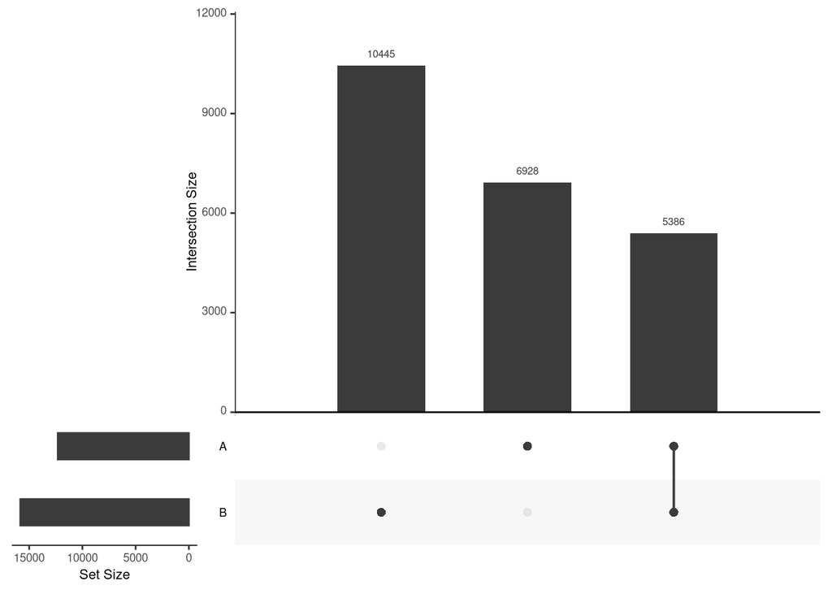

```r
output$upset
```

- **venn**: upset: contains a venn diagram of the intersections of interactions

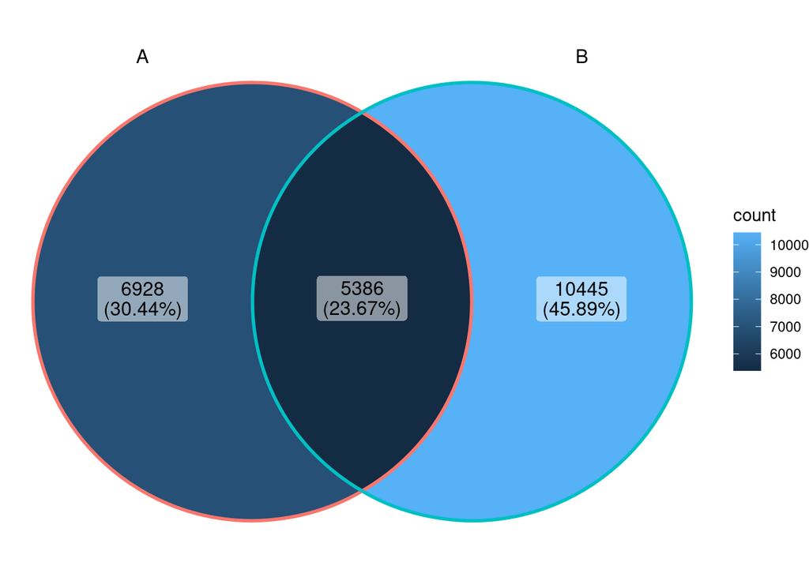

```r
output$venn
```

# Summarise interactions by distance: `distance_summary`

This function allows us to get a summary of the number of interactions by their distance. This is interesting to compare the profile of distances between conditions.

```r
dist_sum <- distance_summary(interactions = ibed_annotated,
                             breaks = seq(0, 10^6, 10^5),
                             sample = "ibed1")
dist_sum
```

```
## # A tibble: 33 × 6
##    int   total_per_int sample HiCaptuRe breaks        value
##    <chr>         <int> <chr>      <int> <fct>         <int>
##  1 Total            NA ibed1      12312 (0,1e+05]      3118
##  2 B_B            2690 ibed1      12312 (0,1e+05]       746
##  3 B_OE           9622 ibed1      12312 (0,1e+05]      2372
##  4 Total            NA ibed1      12312 (1e+05,2e+05]  3176
##  5 B_B            2690 ibed1      12312 (1e+05,2e+05]   644
##  6 B_OE           9622 ibed1      12312 (1e+05,2e+05]  2532
##  7 Total            NA ibed1      12312 (2e+05,3e+05]  2519
##  8 B_B            2690 ibed1      12312 (2e+05,3e+05]   486
##  9 B_OE           9622 ibed1      12312 (2e+05,3e+05]  2033
## 10 Total            NA ibed1      12312 (3e+05,4e+05]  1418
## # ℹ 23 more rows
```

The output is a table with several columns that gives us information of each type of interaction in each range of distance. The columns are:

- **int**. Type of interaction: B_B, B_OE or Total (B_B + B_OE)
- **total_per_int**. Total number of interaction of each type
- **sample**. Name of the sample
- **HiCaptuRe**. Total number of interactions present in the input `HiCaptuRe` object.
- **break**. Distance range
- **value**. Number of interactions of this type in this break.

# Plotting the summary of distance: `plot_distance_summary`

This function plots the output of the previous one. We can plot the values in 3 different ways:

- **Absolute**: the values without any modification.

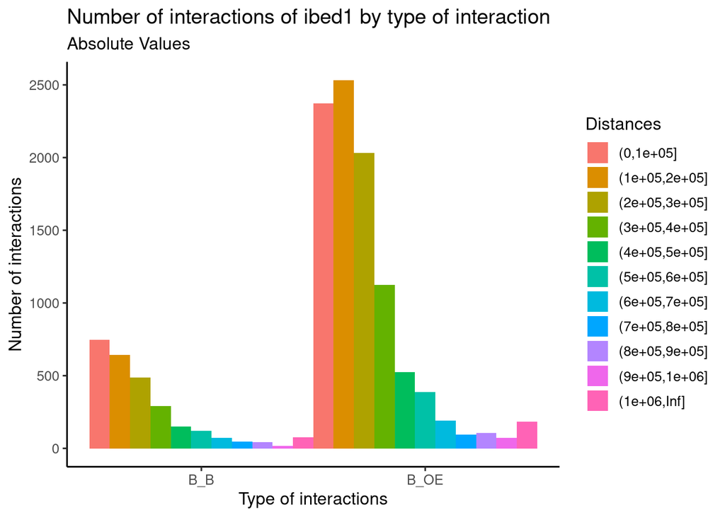

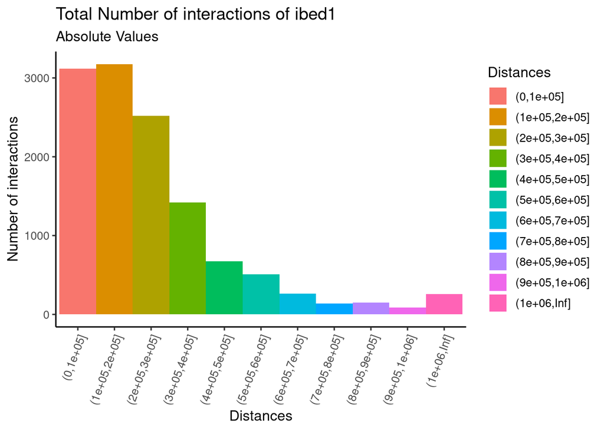

```r
plots <- plot_distance_summary(distances = dist_sum, type_of_value = "absolute")
plots$int_dist
plots$total_dist
```

- **by_int_type**: the values divided by the total number of interactions of each type.

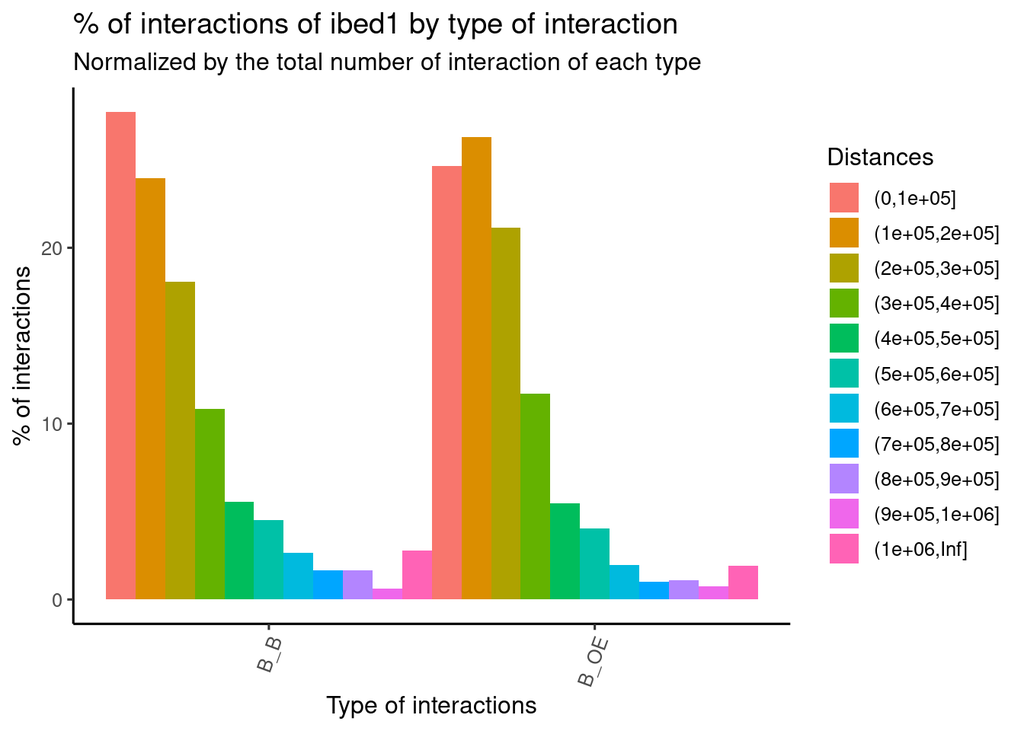

```r
plots <- plot_distance_summary(distances = dist_sum, type_of_value = "by_int_type")
plots$int_dist_norm_int
```

- **by_total**: the values divided by the total number of interactions in the `HiCaptuRe` object.

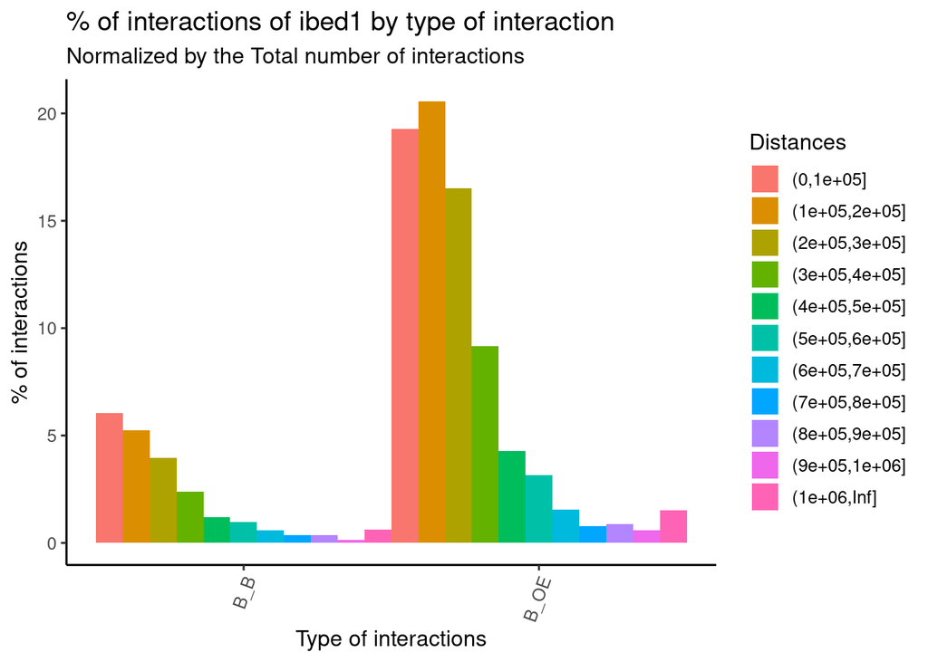

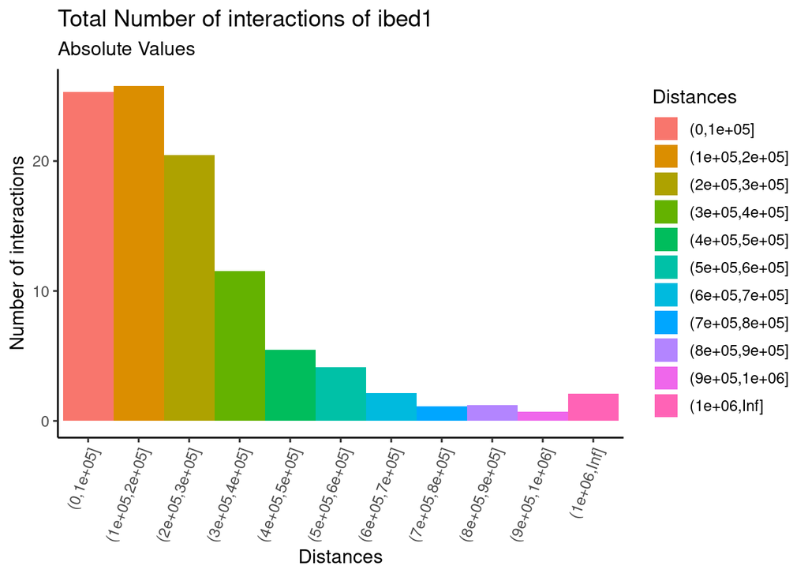

```r
plots <- plot_distance_summary(distances = dist_sum, type_of_value = "by_total")
plots$int_dist_norm_total
plots$total_dist_norm_total
```

# Exporting proccessed interaction data: `export_interactions`

This is the final function. It used to export the interactions that we have generated using all the previous functions.

The `HiCaptuRe` object can be exported in several different format, being the default **ibed** format. The other formats are: peakmatrix, washU, washUold, cytoscape and bedpe.

```r
export_interactions(interactions = ibed_annotated,
                    file = "/path/to/folder/ibed_annotated.ibed",
                    type = "ibed")
```

**NOTE**: the peakmatrix format can only be used if the **HiCaptuRe** object comes from a peakmatrix. And if you want to export a peakmatrix in any other format several files will be exported, one per each sample present in the peakmatrix.